# Label-Agnostic SATURN: Full Experiment Walkthrough

This notebook presents the complete benchmark cell by cell: data inspection, shared SATURN pretraining, the labeled baseline, construction and auditing of the label-free training artifact, InfoNCE, MMD, partial OT, post-hoc evaluation, and the final figures.

## Experiment design

All four trials begin from the same pretrained SATURN checkpoint.

- **Baseline:** SATURN's original label-aware triplet fine-tuning.
- **InfoNCE:** reciprocal cross-species neighbours inferred from pretrained embeddings and macrogenes.
- **MMD:** pairwise multi-species distribution matching.
- **OT:** entropy-regularized partial optimal transport.

The three label-free trainers can access only embeddings, macrogenes, species identity, and observation IDs. Cell labels are introduced only after training by the shared evaluator.

```python
from pathlib import Path
import json
import os
import shlex
import subprocess
import sys
import time

import anndata as ad
import matplotlib.pyplot as plt
import numpy as np
import pandas as pd
import scanpy as sc
import seaborn as sns
import torch
from IPython.display import Markdown, display

repo_root = next((
    candidate
    for candidate in (Path.cwd(), *Path.cwd().parents)
    if (candidate / 'scripts' / 'human_monkey_mouse.sh').exists()
), None)
if repo_root is None:
    raise FileNotFoundError('Could not locate the macrogenes repository.')
if str(repo_root) not in sys.path:
    sys.path.insert(0, str(repo_root))

# Presentation mode: reuse the completed run and reproduce its exact outputs.
REBUILD_FROM_SCRATCH = False

canonical_output_dir = repo_root / 'out' / 'human_monkey_mouse_benchmark_clean'
fresh_output_dir = repo_root / 'out' / 'human_monkey_mouse_benchmark_walkthrough'
output_dir = fresh_output_dir if REBUILD_FROM_SCRATCH else fresh_output_dir

SEED = 0
DEVICE = 'cuda'
DEVICE_NUM = 0
EPOCHS = 20
BATCH_SIZE = 512
TRIALS = ['baseline', 'infonce', 'mmd', 'ot']

if REBUILD_FROM_SCRATCH and output_dir == canonical_output_dir:
    raise RuntimeError('Fresh runs must not overwrite the canonical presentation outputs.')
if REBUILD_FROM_SCRATCH and not torch.cuda.is_available():
    raise RuntimeError('A system GPU is required for a fresh run.')

shared_dir = output_dir / 'shared'
baseline_dir = output_dir / 'baseline'
pretrain_model = shared_dir / 'pretrain_model.pt'
centroids = shared_dir / f'centroids_seed{SEED}.pkl'
baseline_model = baseline_dir / 'final_model.pt'
pretrain_adata = baseline_dir / 'saturn_results' / 'adata_pretrain.h5ad'
baseline_adata = baseline_dir / 'saturn_results' / 'final_adata.h5ad'
label_free_artifact = shared_dir / 'label_free_artifact.npz'
evaluation_triplets = shared_dir / 'evaluation_triplets.npz'
artifact_metadata = shared_dir / 'artifact_metadata.json'

shared_dir.mkdir(parents=True, exist_ok=True)
baseline_dir.mkdir(parents=True, exist_ok=True)

base_env = os.environ.copy()
base_env.update({
    'PYTHONHASHSEED': str(SEED),
    'NUMBA_NUM_THREADS': '1',
    'NUMBA_CACHE_DIR': '/tmp/macrogenes-numba-cache',
    'MPLCONFIGDIR': '/tmp/macrogenes-matplotlib',
})

def make_label_palette(labels):
    label_index = pd.Index(pd.Series(labels).astype(str).dropna().unique()).sort_values()
    colors = sns.color_palette('husl', n_colors=len(label_index)).as_hex()
    return dict(zip(label_index, colors))

def run_stage(name, command, required_outputs, env=None):
    required_outputs = [Path(path) for path in required_outputs]
    if not REBUILD_FROM_SCRATCH and all(path.exists() for path in required_outputs):
        print(f'✓ {name}: reusing completed outputs')
        for path in required_outputs:
            print(f'  {path.relative_to(repo_root)}')
        return
    print(f'▶ {name}')
    print('  $', shlex.join([str(part) for part in command]))
    started = time.time()
    subprocess.run(
        [str(part) for part in command],
        cwd=repo_root,
        env=env or base_env,
        check=True,
    )
    missing = [path for path in required_outputs if not path.exists()]
    if missing:
        raise FileNotFoundError(f'{name} did not create: {missing}')
    print(f'✓ {name}: completed in {(time.time() - started) / 60:.1f} minutes')

print(f'Repository: {repo_root}')
print(f'Python environment: {sys.prefix}')
print(f'Output directory: {output_dir}')
print(f'Mode: {"fresh GPU run" if REBUILD_FROM_SCRATCH else "canonical presentation outputs"}')
```

```
Repository: /home/darcy/projects/SATURN-unsupervised
Python environment: /home/darcy/miniconda3/envs/saturn
Output directory: /home/darcy/projects/SATURN-unsupervised/out/human_monkey_mouse_benchmark_walkthrough
Mode: canonical presentation outputs
```

## 1. Inspect the benchmark data

```python
input_table = pd.read_csv(repo_root / 'data' / 'human_monkey_mouse.csv')
display(input_table)

dataset_rows = []
for row in input_table.itertuples(index=False):
    atlas = ad.read_h5ad(repo_root / row.path, backed='r')
    label_column = row.in_label_col
    dataset_rows.append({
        'species': row.species,
        'cells': atlas.n_obs,
        'genes': atlas.n_vars,
        'label_column': label_column,
        'unique_labels': int(atlas.obs[label_column].nunique()),
    })
    atlas.file.close()

dataset_summary = pd.DataFrame(dataset_rows)
display(dataset_summary)
print(f'Total cells: {dataset_summary.cells.sum():,}')
```

|  | species | path | embedding_path | in_label_col |
| --- | --- | --- | --- | --- |
| 0 | h_sapiens | data/cell_atlases/h_sapiens.h5ad | data/gene_embeddings/esmc600_embeddings_summar... | cellType |
| 1 | m_musculus | data/cell_atlases/m_musculus.h5ad | data/gene_embeddings/esmc600_embeddings_summar... | cellType |
| 2 | m_murinus | data/cell_atlases/m_murinus.h5ad | data/gene_embeddings/esmc600_embeddings_summar... | cellType |

|  | species | cells | genes | label_column | unique_labels |
| --- | --- | --- | --- | --- | --- |
| 0 | h_sapiens | 51881 | 19504 | cellType | 83 |
| 1 | m_musculus | 26947 | 15437 | cellType | 78 |
| 2 | m_murinus | 38276 | 13495 | cellType | 83 |

```
Total cells: 117,104
```

## 2. Shared pretraining and labeled SATURN baseline

This stage performs SATURN pretraining once, saves the shared checkpoint, and then runs the original label-aware metric-learning baseline for 20 epochs.

```python
baseline_env = base_env.copy()
baseline_env.update({
    'SEED': str(SEED),
    'DEVICE': DEVICE,
    'DEVICE_NUM': str(DEVICE_NUM),
    'WORK_DIR': str(baseline_dir) + '/',
    'CENTROIDS_INIT_PATH': str(centroids),
    'PRETRAIN_MODEL_PATH': str(pretrain_model),
    'METRIC_MODEL_PATH': str(baseline_model),
    'PRETRAIN': 'true',
    'METRIC_EPOCHS': str(EPOCHS),
    'METRIC_BATCH_SIZE': str(BATCH_SIZE),
    'POLLING_FREQ': '5',
})

run_stage(
    'shared pretraining + labeled baseline',
    ['bash', repo_root / 'scripts' / 'human_monkey_mouse.sh'],
    [pretrain_model, pretrain_adata, baseline_model, baseline_adata],
    env=baseline_env,
)
```

```
▶ shared pretraining + labeled baseline
  $ bash /home/darcy/projects/SATURN-unsupervised/scripts/human_monkey_mouse.sh
```

```
Using Device 0
Set seed to 0
After loading the anndata h_sapiens View of AnnData object with n_obs × n_vars = 51881 × 19504
    obs: 'organ', 'cellType', 'species', 'species_type_label', 'truth_labels', 'ref_labels'
    obsm: 'X_pca', 'X_scvi', 'X_scvi_umap', 'X_umap'
After loading the anndata m_musculus View of AnnData object with n_obs × n_vars = 26947 × 15437
    obs: 'organ', 'cellType', 'species', 'species_type_label', 'truth_labels', 'ref_labels'
    obsm: 'X_pca', 'X_tsne', 'X_umap'
After loading the anndata m_murinus View of AnnData object with n_obs × n_vars = 38276 × 13495
    obs: 'organ', 'cellType', 'species', 'species_type_label', 'truth_labels', 'ref_labels'
    obsm: 'X_pca', 'X_umap'
    layers: 'raw_counts'
h_sapiens
m_murinus
m_musculus
Making Centroids using KMeans (sklearn, not on GPU) and scoring genes against them
Saved centroids and scores to /home/darcy/projects/SATURN-unsupervised/out/human_monkey_mouse_benchmark_walkthrough/shared/centroids_seed0.pkl
Pretraining...
```

```
Epoch 20: L1 Loss 0.0 Rank Loss 2.284381866455078, Avg Loss h_sapiens: 618, Avg Loss m_murinus: 564, Avg Loss m_musculus: 670: 100%|██████████| 20/20 [04:28<00:00, 13.41s/it]
```

```
Saved Pretrain Model to /home/darcy/projects/SATURN-unsupervised/out/human_monkey_mouse_benchmark_walkthrough/shared/pretrain_model.pt
Loaded Pretrain Model
Saving Pretrain AnnData
```

```
Pretrain losses csv Path: /home/darcy/projects/SATURN-unsupervised/out/human_monkey_mouse_benchmark_walkthrough/baseline/saturn_results/pretrain_losses.csv
-----------------------------
***STARTING METRIC LEARNING***
Using metric miner cross_species with semihard triplets
***STARTING METRIC TRAINING***
Epoch 1 Iteration 0: Loss = 0.09686596691608429, Number of mined triplets = 3113
Epoch 1 Iteration 100: Loss = 0.09777551889419556, Number of mined triplets = 420
Epoch 1 Iteration 200: Loss = 0.08977095037698746, Number of mined triplets = 247
Epoch 2 Iteration 0: Loss = 0.08258377015590668, Number of mined triplets = 245
Epoch 2 Iteration 100: Loss = 0.09481534361839294, Number of mined triplets = 228
Epoch 2 Iteration 200: Loss = 0.08249551802873611, Number of mined triplets = 244
Epoch 3 Iteration 0: Loss = 0.08498048037290573, Number of mined triplets = 255
Epoch 3 Iteration 100: Loss = 0.08967752754688263, Number of mined triplets = 231
Epoch 3 Iteration 200: Loss = 0.09271951764822006, Number of mined triplets = 193
Epoch 4 Iteration 0: Loss = 0.09094098955392838, Number of mined triplets = 241
Epoch 4 Iteration 100: Loss = 0.08612746745347977, Number of mined triplets = 274
Epoch 4 Iteration 200: Loss = 0.10657970607280731, Number of mined triplets = 319
Epoch 5 Iteration 0: Loss = 0.0934176817536354, Number of mined triplets = 156
Epoch 5 Iteration 100: Loss = 0.094147227704525, Number of mined triplets = 164
Epoch 5 Iteration 200: Loss = 0.09652676433324814, Number of mined triplets = 152
```

```
Epoch 6 Iteration 0: Loss = 0.0847833901643753, Number of mined triplets = 225
Epoch 6 Iteration 100: Loss = 0.08163969963788986, Number of mined triplets = 180
Epoch 6 Iteration 200: Loss = 0.09679200500249863, Number of mined triplets = 178
Epoch 7 Iteration 0: Loss = 0.0883297473192215, Number of mined triplets = 179
Epoch 7 Iteration 100: Loss = 0.08061987161636353, Number of mined triplets = 154
Epoch 7 Iteration 200: Loss = 0.08463943749666214, Number of mined triplets = 163
Epoch 8 Iteration 0: Loss = 0.09076349437236786, Number of mined triplets = 229
Epoch 8 Iteration 100: Loss = 0.09684206545352936, Number of mined triplets = 149
Epoch 8 Iteration 200: Loss = 0.0857834666967392, Number of mined triplets = 211
Epoch 9 Iteration 0: Loss = 0.08605208247900009, Number of mined triplets = 183
Epoch 9 Iteration 100: Loss = 0.07887368649244308, Number of mined triplets = 164
Epoch 9 Iteration 200: Loss = 0.0916532576084137, Number of mined triplets = 208
Epoch 10 Iteration 0: Loss = 0.09240112453699112, Number of mined triplets = 128
Epoch 10 Iteration 100: Loss = 0.08359342068433762, Number of mined triplets = 117
Epoch 10 Iteration 200: Loss = 0.07893755286931992, Number of mined triplets = 168
```

```
Epoch 11 Iteration 0: Loss = 0.08824556320905685, Number of mined triplets = 202
Epoch 11 Iteration 100: Loss = 0.07378330826759338, Number of mined triplets = 98
Epoch 11 Iteration 200: Loss = 0.09064612537622452, Number of mined triplets = 163
Epoch 12 Iteration 0: Loss = 0.09042178839445114, Number of mined triplets = 189
Epoch 12 Iteration 100: Loss = 0.08518258482217789, Number of mined triplets = 123
Epoch 12 Iteration 200: Loss = 0.08493973314762115, Number of mined triplets = 119
Epoch 13 Iteration 0: Loss = 0.09079983830451965, Number of mined triplets = 125
Epoch 13 Iteration 100: Loss = 0.08628237992525101, Number of mined triplets = 119
Epoch 13 Iteration 200: Loss = 0.07895690202713013, Number of mined triplets = 174
Epoch 14 Iteration 0: Loss = 0.09075938165187836, Number of mined triplets = 149
Epoch 14 Iteration 100: Loss = 0.07908640056848526, Number of mined triplets = 165
Epoch 14 Iteration 200: Loss = 0.08894318342208862, Number of mined triplets = 132
Epoch 15 Iteration 0: Loss = 0.08712967485189438, Number of mined triplets = 120
Epoch 15 Iteration 100: Loss = 0.08412721753120422, Number of mined triplets = 168
Epoch 15 Iteration 200: Loss = 0.0838237777352333, Number of mined triplets = 155
```

```
Epoch 16 Iteration 0: Loss = 0.09712182730436325, Number of mined triplets = 159
Epoch 16 Iteration 100: Loss = 0.07258890569210052, Number of mined triplets = 127
Epoch 16 Iteration 200: Loss = 0.09696728736162186, Number of mined triplets = 151
Epoch 17 Iteration 0: Loss = 0.06754305213689804, Number of mined triplets = 113
Epoch 17 Iteration 100: Loss = 0.09294111281633377, Number of mined triplets = 122
Epoch 17 Iteration 200: Loss = 0.08189619332551956, Number of mined triplets = 155
Epoch 18 Iteration 0: Loss = 0.08460043370723724, Number of mined triplets = 119
Epoch 18 Iteration 100: Loss = 0.08909521251916885, Number of mined triplets = 138
Epoch 18 Iteration 200: Loss = 0.07527394592761993, Number of mined triplets = 114
Epoch 19 Iteration 0: Loss = 0.08909749239683151, Number of mined triplets = 129
Epoch 19 Iteration 100: Loss = 0.08626120537519455, Number of mined triplets = 154
Epoch 19 Iteration 200: Loss = 0.09493938088417053, Number of mined triplets = 156
Epoch 20 Iteration 0: Loss = 0.10364985466003418, Number of mined triplets = 165
Epoch 20 Iteration 100: Loss = 0.09573867917060852, Number of mined triplets = 144
Epoch 20 Iteration 200: Loss = 0.07985901087522507, Number of mined triplets = 109
```

```
Saving Metric Model to /home/darcy/projects/SATURN-unsupervised/out/human_monkey_mouse_benchmark_walkthrough/baseline/final_model.pt
Saving Final AnnData
```

```
Final AnnData Path: /home/darcy/projects/SATURN-unsupervised/out/human_monkey_mouse_benchmark_walkthrough/baseline/saturn_results/final_adata.h5ad
Final Triplets csv Path: /home/darcy/projects/SATURN-unsupervised/out/human_monkey_mouse_benchmark_walkthrough/baseline/saturn_results/triplets.csv
Final Epoch scores csv Path: /home/darcy/projects/SATURN-unsupervised/out/human_monkey_mouse_benchmark_walkthrough/baseline/saturn_results/epoch_scores.csv
Final Metric history csv Path: /home/darcy/projects/SATURN-unsupervised/out/human_monkey_mouse_benchmark_walkthrough/baseline/saturn_results/metric_history.csv
Final celltype_id Path: /home/darcy/projects/SATURN-unsupervised/out/human_monkey_mouse_benchmark_walkthrough/baseline/saturn_results/celltype_id.pkl
✓ shared pretraining + labeled baseline: completed in 245.3 minutes
```

```python
pretrained = ad.read_h5ad(pretrain_adata, backed='r')
baseline = ad.read_h5ad(baseline_adata, backed='r')
display(pd.DataFrame([
    {'stage': 'pretrained', 'cells': pretrained.n_obs, 'embedding_dim': pretrained.n_vars, 'macrogenes': pretrained.obsm['macrogenes'].shape[1]},
    {'stage': 'labeled baseline', 'cells': baseline.n_obs, 'embedding_dim': baseline.n_vars, 'macrogenes': baseline.obsm['macrogenes'].shape[1]},
]))
pretrained.file.close()
baseline.file.close()
```

|  | stage | cells | embedding_dim | macrogenes |
| --- | --- | --- | --- | --- |
| 0 | pretrained | 117104 | 256 | 200 |
| 1 | labeled baseline | 117104 | 256 | 200 |

### Pretrained representation before fine-tuning

This is the visual starting point for all four trials. Species are initially almost completely separated, while much of the within-species cell-state structure is already present.

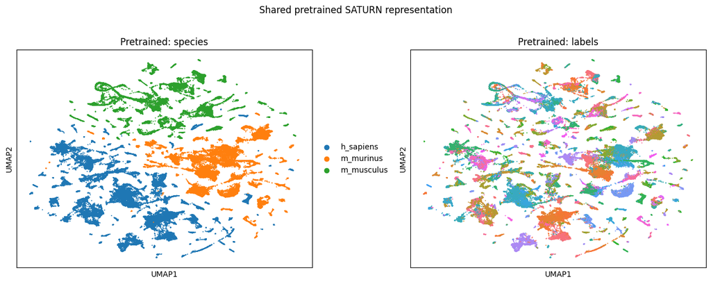

```python
pretrained = ad.read_h5ad(pretrain_adata)
if 'X_umap' not in pretrained.obsm:
    sc.pp.neighbors(pretrained, n_neighbors=15, metric='cosine', random_state=SEED)
    sc.tl.umap(pretrained, min_dist=0.3, random_state=SEED)

def make_label_palette(labels):
    label_index = pd.Index(pd.Series(labels).astype(str).dropna().unique()).sort_values()
    colors = sns.color_palette('husl', n_colors=len(label_index)).as_hex()
    return dict(zip(label_index, colors))

label_palette = make_label_palette(pretrained.obs['labels2'])

fig, axes = plt.subplots(1, 2, figsize=(13, 5))
sc.pl.umap(pretrained, color='species', ax=axes[0], show=False, title='Pretrained: species', size=8)
sc.pl.umap(pretrained, color='labels2', ax=axes[1], show=False, title='Pretrained: labels', size=8, legend_loc=None, palette=label_palette)
fig.suptitle('Shared pretrained SATURN representation', y=1.02)
fig.tight_layout()
plt.show()
```

```python
from label_agnostic.metrics import embedding_benchmark_metrics

pretrained_metrics = embedding_benchmark_metrics(
    np.asarray(pretrained.X),
    pretrained.obs['species'].astype(str).to_numpy(),
    pretrained.obs['labels2'].astype(str).to_numpy(),
    k=15,
)
display(pd.Series(pretrained_metrics, name='pretrained'))
```

```
species_mixing_fraction                        0.000413
label_same_neighbor_fraction                   0.822929
species_macro_mixing_fraction                  0.000418
species_macro_label_same_neighbor_fraction     0.820780
within_species_label_same_neighbor_fraction    0.823016
normalized_species_ilisi                       0.000361
Name: pretrained, dtype: float64
```

## 3. Build and audit the label-free training artifact

The exporter creates two separate files:

1. A strict training artifact with no label arrays.
2. A frozen label-aware triplet manifest used only by the evaluator after all training is complete.

```python
run_stage(
    'label-free artifact + frozen evaluation triplets',
    [
        sys.executable,
        repo_root / 'scripts' / 'prepare_label_agnostic_artifacts.py',
        '--pretrain-adata', pretrain_adata,
        '--artifact', label_free_artifact,
        '--triplets', evaluation_triplets,
        '--metadata', artifact_metadata,
        '--seed', str(SEED),
        '--batch-size', str(BATCH_SIZE),
    ],
    [label_free_artifact, evaluation_triplets, artifact_metadata],
)
```

```
▶ label-free artifact + frozen evaluation triplets
  $ /home/darcy/miniconda3/envs/saturn/bin/python /home/darcy/projects/SATURN-unsupervised/scripts/prepare_label_agnostic_artifacts.py --pretrain-adata /home/darcy/projects/SATURN-unsupervised/out/human_monkey_mouse_benchmark_walkthrough/baseline/saturn_results/adata_pretrain.h5ad --artifact /home/d…
{
  "batch_size": 512,
  "cell_count": 117104,
  "embedding_dimension": 256,
  "evaluation_labels_used_only_here": true,
  "evaluation_triplet_count": 575128,
  "label_free_artifact_keys": [
    "embeddings",
    "macrogenes",
    "species",
    "obs_ids"
  ],
  "macrogene_dimension": 200,
  "schema_version": 1,
  "seed": 0,
  "species": [
    "h_sapiens",
    "m_murinus",
    "m_musculus"
  ]
}
✓ label-free artifact + frozen evaluation triplets: completed in 1.2 minutes
```

```python
training_artifact = np.load(label_free_artifact, allow_pickle=False)
allowed_keys = {'embeddings', 'macrogenes', 'species', 'obs_ids'}
actual_keys = set(training_artifact.files)
assert actual_keys == allowed_keys
assert not any('label' in key.lower() for key in actual_keys)

artifact_audit = pd.DataFrame([
    {'array': key, 'shape': training_artifact[key].shape, 'dtype': str(training_artifact[key].dtype)}
    for key in training_artifact.files
])
display(artifact_audit)
display(json.loads(artifact_metadata.read_text()))
print('✓ No cell-label field is available to label-free fine-tuning.')
```

|  | array | shape | dtype |
| --- | --- | --- | --- |
| 0 | embeddings | (117104, 256) | float32 |
| 1 | macrogenes | (117104, 200) | float32 |
| 2 | species | (117104,) | <U10 |
| 3 | obs_ids | (117104,) | <U95 |

```
{'batch_size': 512,
 'cell_count': 117104,
 'embedding_dimension': 256,
 'evaluation_labels_used_only_here': True,
 'evaluation_triplet_count': 575128,
 'label_free_artifact_keys': ['embeddings',
  'macrogenes',
  'species',
  'obs_ids'],
 'macrogene_dimension': 200,
 'schema_version': 1,
 'seed': 0,
 'species': ['h_sapiens', 'm_murinus', 'm_musculus']}
```

```
✓ No cell-label field is available to label-free fine-tuning.
```

## 4. Run the three label-free objectives

Each trial loads the same four-field artifact and the same pretrained checkpoint. Checkpoint selection uses species mixing subject to a frozen-neighbour recall constraint; labels are never used for optimization or selection.

```python
def run_label_free_trial(objective):
    trial_dir = output_dir / objective
    command = [
        sys.executable,
        repo_root / 'scripts' / 'train_label_agnostic.py',
        '--objective', objective,
        '--artifact', label_free_artifact,
        '--pretrain-checkpoint', pretrain_model,
        '--output-dir', trial_dir,
        '--device', DEVICE,
        '--device-num', str(DEVICE_NUM),
        '--seed', str(SEED),
        '--epochs', 30,
        '--batch-size', str(BATCH_SIZE),
    ]
    run_stage(
        f'{objective} fine-tuning',
        command,
        [trial_dir / 'final_embeddings.npz', trial_dir / 'metric_history.csv', trial_dir / 'run_summary.json'],
    )
    return json.loads((trial_dir / 'run_summary.json').read_text())

def show_trial_summary(summary):
    display(pd.Series({
        'objective': summary['objective'],
        'label_free': summary['label_free'],
        'artifact keys seen': ', '.join(summary['artifact_keys_seen_by_trainer']),
        'selected epoch': summary['selected_epoch'],
        'selected species mixing': summary['selected_species_mixing_fraction'],
        'selected frozen-neighbour recall@50': summary['selected_teacher_top15_recall_at_50'],
        'selection uses labels': summary['selection_uses_labels'],
    }).to_frame('value'))
```

### 4a. InfoNCE

Reciprocal cross-species neighbours inferred from the pretrained embedding/macrogene views serve as positives. Cells from the target species form the contrastive denominator.

```python
infonce_summary = run_label_free_trial('infonce')
show_trial_summary(infonce_summary)
```

```
▶ infonce fine-tuning
  $ /home/darcy/miniconda3/envs/saturn/bin/python /home/darcy/projects/SATURN-unsupervised/scripts/train_label_agnostic.py --objective infonce --artifact /home/darcy/projects/SATURN-unsupervised/out/human_monkey_mouse_benchmark_walkthrough/shared/label_free_artifact.npz --pretrain-checkpoint /home/d…
```

```
Epoch 1: loss=8.560185, mixing=0.0058, recall@50=0.9676, lambda=11.9958
Epoch 2: loss=7.691512, mixing=0.0138, recall@50=0.9229, lambda=7.0236
Epoch 3: loss=7.380908, mixing=0.0241, recall@50=0.8850, lambda=4.4971
Epoch 4: loss=7.171155, mixing=0.0336, recall@50=0.8518, lambda=3.1062
Epoch 5: loss=7.001554, mixing=0.0445, recall@50=0.8195, lambda=2.2929
Epoch 6: loss=6.855548, mixing=0.0505, recall@50=0.7983, lambda=1.8054
Epoch 7: loss=6.746522, mixing=0.0582, recall@50=0.7833, lambda=1.4830
Epoch 8: loss=6.659809, mixing=0.0655, recall@50=0.7705, lambda=1.2553
Epoch 9: loss=6.592555, mixing=0.0701, recall@50=0.7596, lambda=1.0902
Epoch 10: loss=6.528572, mixing=0.0753, recall@50=0.7503, lambda=0.9678
Epoch 11: loss=6.482509, mixing=0.0796, recall@50=0.7409, lambda=0.8751
Epoch 12: loss=6.432476, mixing=0.0831, recall@50=0.7320, lambda=0.8063
Epoch 13: loss=6.414793, mixing=0.0872, recall@50=0.7272, lambda=0.7563
Epoch 14: loss=6.383577, mixing=0.0894, recall@50=0.7216, lambda=0.7163
Epoch 15: loss=6.358090, mixing=0.0909, recall@50=0.7204, lambda=0.6860
Epoch 16: loss=6.329354, mixing=0.0959, recall@50=0.7114, lambda=0.6586
Epoch 17: loss=6.318848, mixing=0.0972, recall@50=0.7101, lambda=0.6438
Epoch 18: loss=6.296830, mixing=0.0999, recall@50=0.7066, lambda=0.6309
Epoch 19: loss=6.282216, mixing=0.1030, recall@50=0.7014, lambda=0.6226
Epoch 20: loss=6.272752, mixing=0.1054, recall@50=0.7002, lambda=0.6209
Epoch 21: loss=6.262137, mixing=0.1062, recall@50=0.6974, lambda=0.6206
Epoch 22: loss=6.246936, mixing=0.1059, recall@50=0.6954, lambda=0.6238
Epoch 23: loss=6.241467, mixing=0.1088, recall@50=0.6925, lambda=0.6296
Epoch 24: loss=6.229713, mixing=0.1082, recall@50=0.6925, lambda=0.6391
Epoch 25: loss=6.227671, mixing=0.1101, recall@50=0.6900, lambda=0.6488
Epoch 26: loss=6.222460, mixing=0.1110, recall@50=0.6898, lambda=0.6620
Epoch 27: loss=6.220453, mixing=0.1109, recall@50=0.6909, lambda=0.6757
Epoch 28: loss=6.213643, mixing=0.1120, recall@50=0.6884, lambda=0.6880
Epoch 29: loss=6.209066, mixing=0.1125, recall@50=0.6871, lambda=0.7042
Epoch 30: loss=6.212177, mixing=0.1156, recall@50=0.6847, lambda=0.7226
{
  "alignment_gradient_norm": 1.0323154926300049,
  "artifact_keys_seen_by_trainer": [
    "embeddings",
    "macrogenes",
    "obs_ids",
    "species"
  ],
  "batch_size": 512,
  "configuration": {
```

[output cut: 32 more lines]

```
  "learning_rate": 0.001,
  "mmd_bandwidth": 1.4248967170715332,
  "objective": "infonce",
  "preservation_gradient_norm": 0.02151409536600113,
  "pretrain_checkpoint_sha256": "5055db3f24a47cfe4ee3c462afd821022a2f707580a1ecb23fe4d274ac3a62dc",
  "schema_version": 1,
  "seed": 0,
  "selected_epoch": 20,
  "selected_species_mixing_fraction": 0.10543448558546249,
  "selected_teacher_top15_recall_at_50": 0.7001804663660793,
  "selection_rule": "maximize species_mixing_fraction subject to teacher_top15_recall_at_50 >= 0.7",
  "selection_uses_labels": false,
  "trainer_version": 4
}
✓ infonce fine-tuning: completed in 220.7 minutes
```

|  | value |
| --- | --- |
| objective | infonce |
| label_free | True |
| artifact keys seen | embeddings, macrogenes, obs_ids, species |
| selected epoch | 20 |
| selected species mixing | 0.105434 |
| selected frozen-neighbour recall@50 | 0.70018 |
| selection uses labels | False |

### 4b. MMD

A multi-bandwidth RBF maximum mean discrepancy is averaged across every species pair.

```python
mmd_summary = run_label_free_trial('mmd')
show_trial_summary(mmd_summary)
```

```
▶ mmd fine-tuning
  $ /home/darcy/miniconda3/envs/saturn/bin/python /home/darcy/projects/SATURN-unsupervised/scripts/train_label_agnostic.py --objective mmd --artifact /home/darcy/projects/SATURN-unsupervised/out/human_monkey_mouse_benchmark_walkthrough/shared/label_free_artifact.npz --pretrain-checkpoint /home/darcy…
```

```
Epoch 1: loss=1.465278, mixing=0.0012, recall@50=0.9860, lambda=1.8123
Epoch 2: loss=1.310178, mixing=0.0018, recall@50=0.9546, lambda=1.0229
Epoch 3: loss=1.228545, mixing=0.0025, recall@50=0.9221, lambda=0.6147
Epoch 4: loss=1.166242, mixing=0.0033, recall@50=0.8920, lambda=0.3943
Epoch 5: loss=1.117074, mixing=0.0039, recall@50=0.8684, lambda=0.2685
Epoch 6: loss=1.084249, mixing=0.0045, recall@50=0.8500, lambda=0.1917
Epoch 7: loss=1.060599, mixing=0.0049, recall@50=0.8348, lambda=0.1421
Epoch 8: loss=1.042330, mixing=0.0052, recall@50=0.8227, lambda=0.1085
Epoch 9: loss=1.028173, mixing=0.0055, recall@50=0.8113, lambda=0.0849
Epoch 10: loss=1.016329, mixing=0.0061, recall@50=0.8021, lambda=0.0679
Epoch 11: loss=1.006828, mixing=0.0065, recall@50=0.7955, lambda=0.0554
Epoch 12: loss=0.999773, mixing=0.0070, recall@50=0.7883, lambda=0.0458
Epoch 13: loss=0.995784, mixing=0.0071, recall@50=0.7839, lambda=0.0384
Epoch 14: loss=0.990474, mixing=0.0076, recall@50=0.7789, lambda=0.0324
Epoch 15: loss=0.986177, mixing=0.0080, recall@50=0.7739, lambda=0.0277
Epoch 16: loss=0.983325, mixing=0.0081, recall@50=0.7707, lambda=0.0239
Epoch 17: loss=0.980220, mixing=0.0085, recall@50=0.7678, lambda=0.0207
Epoch 18: loss=0.978246, mixing=0.0086, recall@50=0.7648, lambda=0.0181
Epoch 19: loss=0.975383, mixing=0.0089, recall@50=0.7619, lambda=0.0159
Epoch 20: loss=0.973331, mixing=0.0092, recall@50=0.7589, lambda=0.0141
Epoch 21: loss=0.973395, mixing=0.0094, recall@50=0.7561, lambda=0.0125
Epoch 22: loss=0.971579, mixing=0.0097, recall@50=0.7540, lambda=0.0112
Epoch 23: loss=0.970193, mixing=0.0095, recall@50=0.7529, lambda=0.0100
Epoch 24: loss=0.968279, mixing=0.0099, recall@50=0.7496, lambda=0.0090
Epoch 25: loss=0.966884, mixing=0.0097, recall@50=0.7489, lambda=0.0082
Epoch 26: loss=0.965863, mixing=0.0102, recall@50=0.7470, lambda=0.0074
Epoch 27: loss=0.966519, mixing=0.0097, recall@50=0.7463, lambda=0.0067
Epoch 28: loss=0.964359, mixing=0.0102, recall@50=0.7440, lambda=0.0061
Epoch 29: loss=0.963604, mixing=0.0101, recall@50=0.7432, lambda=0.0056
Epoch 30: loss=0.963546, mixing=0.0105, recall@50=0.7421, lambda=0.0052
{
  "alignment_gradient_norm": 0.15595965087413788,
  "artifact_keys_seen_by_trainer": [
    "embeddings",
    "macrogenes",
    "obs_ids",
    "species"
  ],
  "batch_size": 512,
  "configuration": {
```

[output cut: 32 more lines]

```
  "learning_rate": 0.001,
  "mmd_bandwidth": 1.4248967170715332,
  "objective": "mmd",
  "preservation_gradient_norm": 0.02151409536600113,
  "pretrain_checkpoint_sha256": "5055db3f24a47cfe4ee3c462afd821022a2f707580a1ecb23fe4d274ac3a62dc",
  "schema_version": 1,
  "seed": 0,
  "selected_epoch": 30,
  "selected_species_mixing_fraction": 0.010467618527121192,
  "selected_teacher_top15_recall_at_50": 0.7421181172291297,
  "selection_rule": "maximize species_mixing_fraction subject to teacher_top15_recall_at_50 >= 0.7",
  "selection_uses_labels": false,
  "trainer_version": 4
}
✓ mmd fine-tuning: completed in 429.6 minutes
```

|  | value |
| --- | --- |
| objective | mmd |
| label_free | True |
| artifact keys seen | embeddings, macrogenes, obs_ids, species |
| selected epoch | 30 |
| selected species mixing | 0.010468 |
| selected frozen-neighbour recall@50 | 0.742118 |
| selection uses labels | False |

### 4c. Partial optimal transport

A frozen cost based on pretrained embeddings and macrogenes defines an entropy-regularized partial transport plan. The student minimizes the transported embedding cost.

```python
ot_summary = run_label_free_trial('ot')
show_trial_summary(ot_summary)
```

```
▶ ot fine-tuning
  $ /home/darcy/miniconda3/envs/saturn/bin/python /home/darcy/projects/SATURN-unsupervised/scripts/train_label_agnostic.py --objective ot --artifact /home/darcy/projects/SATURN-unsupervised/out/human_monkey_mouse_benchmark_walkthrough/shared/label_free_artifact.npz --pretrain-checkpoint /home/darcy/…
```

```
Epoch 1: loss=2.061281, mixing=0.0020, recall@50=0.9818, lambda=2.5452
Epoch 2: loss=1.999938, mixing=0.0070, recall@50=0.9457, lambda=1.4485
Epoch 3: loss=1.983989, mixing=0.0125, recall@50=0.9117, lambda=0.8862
Epoch 4: loss=1.977552, mixing=0.0165, recall@50=0.8840, lambda=0.5803
Epoch 5: loss=1.971377, mixing=0.0197, recall@50=0.8623, lambda=0.4016
Epoch 6: loss=1.964953, mixing=0.0223, recall@50=0.8435, lambda=0.2903
Epoch 7: loss=1.966783, mixing=0.0234, recall@50=0.8286, lambda=0.2179
Epoch 8: loss=1.961431, mixing=0.0248, recall@50=0.8156, lambda=0.1685
Epoch 9: loss=1.965905, mixing=0.0262, recall@50=0.8039, lambda=0.1337
Epoch 10: loss=1.953894, mixing=0.0272, recall@50=0.7938, lambda=0.1086
Epoch 11: loss=1.962626, mixing=0.0281, recall@50=0.7861, lambda=0.0900
Epoch 12: loss=1.949801, mixing=0.0285, recall@50=0.7784, lambda=0.0758
Epoch 13: loss=1.950980, mixing=0.0282, recall@50=0.7715, lambda=0.0648
Epoch 14: loss=1.944190, mixing=0.0294, recall@50=0.7655, lambda=0.0562
Epoch 15: loss=1.943429, mixing=0.0300, recall@50=0.7591, lambda=0.0493
Epoch 16: loss=1.942253, mixing=0.0296, recall@50=0.7554, lambda=0.0438
Epoch 17: loss=1.940902, mixing=0.0300, recall@50=0.7504, lambda=0.0392
Epoch 18: loss=1.939211, mixing=0.0312, recall@50=0.7468, lambda=0.0354
Epoch 19: loss=1.924423, mixing=0.0305, recall@50=0.7431, lambda=0.0322
Epoch 20: loss=1.943753, mixing=0.0314, recall@50=0.7405, lambda=0.0296
Epoch 21: loss=1.930350, mixing=0.0312, recall@50=0.7388, lambda=0.0273
Epoch 22: loss=1.927167, mixing=0.0309, recall@50=0.7365, lambda=0.0252
Epoch 23: loss=1.937733, mixing=0.0317, recall@50=0.7331, lambda=0.0235
Epoch 24: loss=1.924430, mixing=0.0309, recall@50=0.7313, lambda=0.0220
Epoch 25: loss=1.939149, mixing=0.0308, recall@50=0.7294, lambda=0.0206
Epoch 26: loss=1.920392, mixing=0.0310, recall@50=0.7284, lambda=0.0195
Epoch 27: loss=1.916941, mixing=0.0298, recall@50=0.7266, lambda=0.0184
Epoch 28: loss=1.943468, mixing=0.0310, recall@50=0.7233, lambda=0.0174
Epoch 29: loss=1.913128, mixing=0.0304, recall@50=0.7223, lambda=0.0166
Epoch 30: loss=1.932719, mixing=0.0310, recall@50=0.7190, lambda=0.0159
{
  "alignment_gradient_norm": 0.21902836859226227,
  "artifact_keys_seen_by_trainer": [
    "embeddings",
    "macrogenes",
    "obs_ids",
    "species"
  ],
  "batch_size": 512,
  "configuration": {
```

[output cut: 32 more lines]

```
  "learning_rate": 0.001,
  "mmd_bandwidth": 1.4248967170715332,
  "objective": "ot",
  "preservation_gradient_norm": 0.02151409536600113,
  "pretrain_checkpoint_sha256": "5055db3f24a47cfe4ee3c462afd821022a2f707580a1ecb23fe4d274ac3a62dc",
  "schema_version": 1,
  "seed": 0,
  "selected_epoch": 23,
  "selected_species_mixing_fraction": 0.031680102017579814,
  "selected_teacher_top15_recall_at_50": 0.7331044769321856,
  "selection_rule": "maximize species_mixing_fraction subject to teacher_top15_recall_at_50 >= 0.7",
  "selection_uses_labels": false,
  "trainer_version": 4
}
✓ ot fine-tuning: completed in 257.5 minutes
```

|  | value |
| --- | --- |
| objective | ot |
| label_free | True |
| artifact keys seen | embeddings, macrogenes, obs_ids, species |
| selected epoch | 23 |
| selected species mixing | 0.03168 |
| selected frozen-neighbour recall@50 | 0.733104 |
| selection uses labels | False |

## 5. Shared post-hoc evaluation

Only now are labels joined back by observation ID. Every trial receives the same cosine 15-neighbour metrics, frozen triplet-margin evaluation, deterministic UMAP settings, and output schema.

```python
run_stage(
    'shared post-hoc evaluation',
    [
        sys.executable,
        repo_root / 'scripts' / 'evaluate_label_agnostic_benchmark.py',
        '--root', output_dir,
        '--truth-adata', pretrain_adata,
        '--triplets', evaluation_triplets,
        '--seed', str(SEED),
    ],
    [
        output_dir / 'comparison.csv',
        output_dir / 'acceptance.json',
        *[output_dir / trial / 'evaluated_adata.h5ad' for trial in TRIALS],
    ],
)
```

```
▶ shared post-hoc evaluation
  $ /home/darcy/miniconda3/envs/saturn/bin/python /home/darcy/projects/SATURN-unsupervised/scripts/evaluate_label_agnostic_benchmark.py --root /home/darcy/projects/SATURN-unsupervised/out/human_monkey_mouse_benchmark_walkthrough --truth-adata /home/darcy/projects/SATURN-unsupervised/out/human_monkey…
```

```
   trial  label_free  selected_epoch  native_objective_loss  species_mixing_fraction  label_same_neighbor_fraction  species_macro_mixing_fraction  species_macro_label_same_neighbor_fraction  within_species_label_same_neighbor_fraction  normalized_species_ilisi  fixed_triplet_margin_loss  fixed_tripl…
baseline       False              20               0.085139                 0.097703                      0.796051                       0.094856                                    0.790371                                     0.811329                  0.095423                   0.046144             …
 infonce        True              20               6.272752                 0.105434                      0.748705                       0.105942                                    0.746670                                     0.777691                  0.097314                   0.092330             …
     mmd        True              30               0.963546                 0.010468                      0.822389                       0.011160                                    0.819067                                     0.825942                  0.010151                   0.169671             …
      ot        True              23               1.937733                 0.031679                      0.806267                       0.030234                                    0.802451                                     0.813035                  0.027946                   0.056483             …
{
  "baseline": {
    "fixed_triplet_margin_loss": 0.046143628656864166,
    "label_same_neighbor_fraction": 0.7960508038438766,
    "species_mixing_fraction": 0.09770289657056978
  },
  "passing_label_free_trials": [],
  "success": false,
  "thresholds": {
    "fixed_triplet_margin_loss_max": 0.06614362865686417,
    "label_same_neighbor_fraction_min": 0.7460508038438766,
    "species_mixing_fraction_min": 0.06770289657056978
  }
}
✓ shared post-hoc evaluation: completed in 37.5 minutes
```

## 6. Results

The remaining cells are the same result views as the compact benchmark notebook.

```python
summary = pd.read_csv(output_dir / 'comparison.csv')
acceptance = json.loads((output_dir / 'acceptance.json').read_text())

display(summary)
display(acceptance)
```

|  | trial | label_free | selected_epoch | native_objective_loss | species_mixing_fraction | label_same_neighbor_fraction | species_macro_mixing_fraction | species_macro_label_same_neighbor_fraction | within_species_label_same_neighbor_fraction | normalized_species_ilisi | fixed_triplet_margin_loss | fixed_triplet_active_fraction | fixed_triplet_ap_similarity | fixed_triplet_an_similarity | fixed_triplet_count | passes_loss | passes_label_same_neighbor | passes_species_mixing | passes_all |
| --- | --- | --- | --- | --- | --- | --- | --- | --- | --- | --- | --- | --- | --- | --- | --- | --- | --- | --- | --- |
| 0 | baseline | False | 20 | 0.085139 | 0.097703 | 0.796051 | 0.094856 | 0.790371 | 0.811329 | 0.095423 | 0.046144 | 0.222909 | 0.596774 | 0.069619 | 575128 | True | True | True | True |
| 1 | infonce | True | 20 | 6.272752 | 0.105434 | 0.748705 | 0.105942 | 0.746670 | 0.777691 | 0.097314 | 0.092330 | 0.644924 | 0.213090 | 0.049569 | 575128 | False | True | True | False |
| 2 | mmd | True | 30 | 0.963546 | 0.010468 | 0.822389 | 0.011160 | 0.819067 | 0.825942 | 0.010151 | 0.169671 | 0.916521 | 0.066195 | 0.027488 | 575128 | False | True | False | False |
| 3 | ot | True | 23 | 1.937733 | 0.031679 | 0.806267 | 0.030234 | 0.802451 | 0.813035 | 0.027946 | 0.056483 | 0.391130 | 0.604692 | 0.350815 | 575128 | True | True | False | False |

```
{'baseline': {'fixed_triplet_margin_loss': 0.046143628656864166,
  'label_same_neighbor_fraction': 0.7960508038438766,
  'species_mixing_fraction': 0.09770289657056978},
 'passing_label_free_trials': [],
 'success': False,
 'thresholds': {'fixed_triplet_margin_loss_max': 0.06614362865686417,
  'label_same_neighbor_fraction_min': 0.7460508038438766,
  'species_mixing_fraction_min': 0.06770289657056978}}
```

```python
if not REBUILD_FROM_SCRATCH:
    compact_summary = pd.read_csv(canonical_output_dir / 'comparison.csv')
    pd.testing.assert_frame_equal(summary, compact_summary, check_exact=True)
    print('✓ Comparison table is byte-for-byte equivalent at the parsed value level to the compact notebook input.')
else:
    print('Fresh run complete. CUDA kernels can introduce very small platform-level numerical variation.')
```

[output not shown]

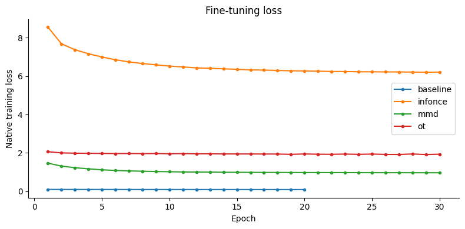

```python
assets = output_dir / 'report_assets'
assets.mkdir(parents=True, exist_ok=True)

fig, ax = plt.subplots(figsize=(8, 4))
for trial in TRIALS:
    history = pd.read_csv(output_dir / trial / 'history.csv')
    ax.plot(history['epoch'], history['metric_loss'], marker='o', ms=3, label=trial)
ax.set(xlabel='Epoch', ylabel='Native training loss', title='Fine-tuning loss')
ax.legend()
sns.despine()
fig.tight_layout()
fig.savefig(assets / 'loss_histories.png', dpi=180)
plt.show()
```

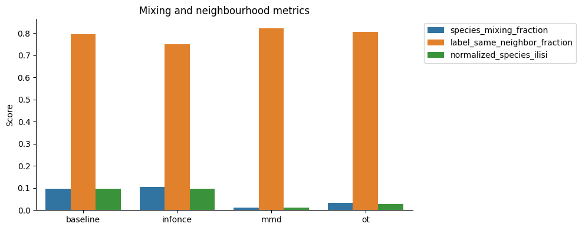

```python
plot_frame = summary.melt(
    id_vars='trial',
    value_vars=['species_mixing_fraction', 'label_same_neighbor_fraction', 'normalized_species_ilisi'],
    var_name='metric', value_name='value',
)
fig, ax = plt.subplots(figsize=(10, 4))
sns.barplot(data=plot_frame, x='trial', y='value', hue='metric', ax=ax)
ax.set(title='Mixing and neighbourhood metrics', xlabel=None, ylabel='Score')
ax.legend(bbox_to_anchor=(1.02, 1), loc='upper left')
sns.despine()
fig.tight_layout()
fig.savefig(assets / 'mixing_metrics.png', dpi=180)
plt.show()
```

[output not shown]

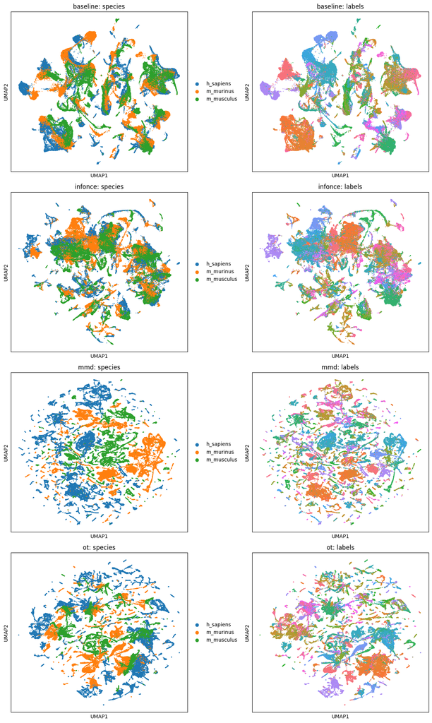

```python
if 'label_palette' not in globals():
    truth_for_palette = ad.read_h5ad(pretrain_adata, backed='r')
    label_palette = make_label_palette(truth_for_palette.obs['labels2'])
    truth_for_palette.file.close()

fig, axes = plt.subplots(len(TRIALS), 2, figsize=(12, 20))
for row, trial in enumerate(TRIALS):
    trial_adata = sc.read_h5ad(output_dir / trial / 'evaluated_adata.h5ad')
    sc.pl.umap(trial_adata, color='species', ax=axes[row, 0], show=False, title=f'{trial}: species', size=8)
    sc.pl.umap(trial_adata, color='labels2', ax=axes[row, 1], show=False, title=f'{trial}: labels', size=8, legend_loc=None, palette=label_palette)
fig.tight_layout()
fig.savefig(assets / 'trial_umaps.png', dpi=180, bbox_inches='tight')
plt.show()
```

```python
import plotly.graph_objects as go
from plotly.subplots import make_subplots

if 'label_palette' not in globals():
    truth_for_palette = ad.read_h5ad(pretrain_adata, backed='r')
    label_palette = make_label_palette(truth_for_palette.obs['labels2'])
    truth_for_palette.file.close()

interactive_trials = ['baseline', 'infonce']
fig = make_subplots(
    rows=1,
    cols=len(interactive_trials),
    subplot_titles=['baseline', 'InfoNCE'],
    horizontal_spacing=0.04,
)

for col, trial in enumerate(interactive_trials, start=1):
    trial_adata = sc.read_h5ad(output_dir / trial / 'evaluated_adata.h5ad')
    hover_frame = pd.DataFrame({
        'umap_1': trial_adata.obsm['X_umap'][:, 0],
        'umap_2': trial_adata.obsm['X_umap'][:, 1],
        'obs_id': trial_adata.obs_names.astype(str),
        'species': trial_adata.obs['species'].astype(str).to_numpy(),
        'cell_type': trial_adata.obs['labels2'].astype(str).to_numpy(),
    })
    point_colors = hover_frame['cell_type'].map(label_palette).fillna('#808080')
    fig.add_trace(
        go.Scattergl(
            x=hover_frame['umap_1'],
            y=hover_frame['umap_2'],
            mode='markers',
            marker={'size': 3, 'color': point_colors, 'opacity': 0.75},
            customdata=hover_frame[['obs_id', 'species', 'cell_type']].to_numpy(),
            hovertemplate=(
                'obs_id=%{customdata[0]}<br>'
                'species=%{customdata[1]}<br>'
                'cell_type=%{customdata[2]}'
                f'<extra>{trial}</extra>'
            ),
            showlegend=False,
        ),
        row=1,
        col=col,
    )

fig.update_layout(
    title='Interactive UMAP hover: baseline vs InfoNCE',
    template='plotly_white',
    width=1150,
    height=560,
    margin={'l': 20, 'r': 20, 't': 70, 'b': 20},
)
for col in range(1, len(interactive_trials) + 1):
    fig.update_xaxes(title_text='UMAP 1', showgrid=False, zeroline=False, row=1, col=col)
    fig.update_yaxes(title_text='UMAP 2', showgrid=False, zeroline=False, row=1, col=col)
fig.show()
```

[output not shown]

```python
import yaml
import plotly.graph_objects as go
from plotly.subplots import make_subplots

macro_category_palette = {
    'immune': '#4C78A8',
    'epithelial': '#F58518',
    'endothelial': "#4FA146",
    'mesenchymal': '#B279A2',
    'other': '#8C8C8C',
    'unknown': '#D0D0D0',
}

species_to_macro_category = {}
macro_category_order = None
for species in input_table['species'].astype(str):
    ontology_path = repo_root / 'data' / 'cell_type_ontology' / f'{species}.yml'
    with ontology_path.open() as handle:
        cell_annotations = yaml.safe_load(handle)['cell_annotations']
    supertypes = cell_annotations['cell_supertypes']
    species_order = [str(category) for category in cell_annotations['supertype_order']]
    if macro_category_order is None:
        macro_category_order = species_order
    elif species_order != macro_category_order:
        raise ValueError(f'Ontology supertype order differs for {species}: {species_order}')

    label_to_category = {}
    for category in species_order:
        for label in supertypes[category]:
            label_to_category[str(label)] = category
    species_to_macro_category[species] = label_to_category

plot_category_order = [*macro_category_order, 'unknown']
interactive_trials = ['baseline', 'infonce']
fig = make_subplots(
    rows=1,
    cols=len(interactive_trials),
    subplot_titles=['baseline', 'InfoNCE'],
    horizontal_spacing=0.04,
)

for col, trial in enumerate(interactive_trials, start=1):
    trial_adata = sc.read_h5ad(output_dir / trial / 'evaluated_adata.h5ad')
    hover_frame = pd.DataFrame({
        'umap_1': trial_adata.obsm['X_umap'][:, 0],
        'umap_2': trial_adata.obsm['X_umap'][:, 1],
        'obs_id': trial_adata.obs_names.astype(str),
        'species': trial_adata.obs['species'].astype(str).to_numpy(),
        'cell_type': trial_adata.obs['labels2'].astype(str).to_numpy(),
    })
    hover_frame['macro_category'] = [
        species_to_macro_category.get(species, {}).get(cell_type, 'unknown')
        for species, cell_type in zip(hover_frame['species'], hover_frame['cell_type'])
    ]

    for category in plot_category_order:
        category_frame = hover_frame[hover_frame['macro_category'] == category]
        if category_frame.empty:
            continue
        fig.add_trace(
            go.Scattergl(
                x=category_frame['umap_1'],
                y=category_frame['umap_2'],
                mode='markers',
                marker={'size': 3, 'color': macro_category_palette[category], 'opacity': 0.75},
                customdata=category_frame[['obs_id', 'species', 'cell_type', 'macro_category']].to_numpy(),
                hovertemplate=(
                    'obs_id=%{customdata[0]}<br>'
                    'species=%{customdata[1]}<br>'
                    'macro_category=%{customdata[3]}<br>'
                    'cell_type=%{customdata[2]}'
                    f'<extra>{trial}</extra>'
                ),
                name=category,
                legendgroup=category,
                showlegend=(col == 1),
            ),
            row=1,
            col=col,
        )

fig.update_layout(
    title='Interactive UMAP hover: baseline vs InfoNCE macro categories',
    template='plotly_white',
    width=1150,
    height=560,
    margin={'l': 20, 'r': 20, 't': 70, 'b': 20},
    legend_title_text='Macro category',
)
for col in range(1, len(interactive_trials) + 1):
    fig.update_xaxes(title_text='UMAP 1', showgrid=False, zeroline=False, row=1, col=col)
    fig.update_yaxes(title_text='UMAP 2', showgrid=False, zeroline=False, row=1, col=col)
fig.show()
```

[output not shown]